# Ch 12-13 r4ds hw

## 13.4.6 Exercises

1. **Compute the average delay by destination, then join on the `airports` data frame so you can show the spatial distribution of delays. Here’s an easy way to draw a map of the United States:**

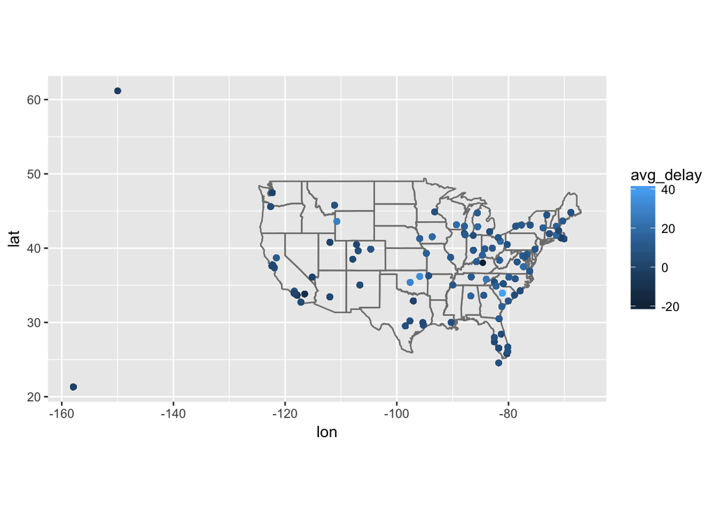

```r
flights3 <- group_by(flights, dest) %>%
mutate(avg_delay = mean(arr_delay, na.rm = T))

flights3 %>%
      left_join(airports, c("dest" = "faa")) %>%
      ggplot(aes(lon, lat)) +
        borders("state") +
        geom_point(aes(color = avg_delay), na.rm = T) +
        coord_quickmap()
```

**(Don’t worry if you don’t understand what `semi_join()` does — you’ll learn about it next.)

```
You might want to use the `size` or `colour` of the points to display
the average delay for each airport.**
```

2. **Add the location of the origin *and* destination (i.e. the `lat` and `lon`) to `flights`.**

```r
flights %>%
left_join(airports, by = c("dest" = "faa"), suffix = c(".d",".o")) %>%
left_join(airports, by = c("origin" = "faa"), suffix = c(".d", ".o"))
```

```
## # A tibble: 336,776 x 33
##     year month   day dep_time sched_dep_time dep_delay arr_time
##    <int> <int> <int>    <int>          <int>     <dbl>    <int>
##  1  2013     1     1      517            515         2      830
##  2  2013     1     1      533            529         4      850
##  3  2013     1     1      542            540         2      923
##  4  2013     1     1      544            545        -1     1004
##  5  2013     1     1      554            600        -6      812
##  6  2013     1     1      554            558        -4      740
##  7  2013     1     1      555            600        -5      913
##  8  2013     1     1      557            600        -3      709
##  9  2013     1     1      557            600        -3      838
## 10  2013     1     1      558            600        -2      753
## # ... with 336,766 more rows, and 26 more variables: sched_arr_time <int>,
## #   arr_delay <dbl>, carrier <chr>, flight <int>, tailnum <chr>,
## #   origin <chr>, dest <chr>, air_time <dbl>, distance <dbl>, hour <dbl>,
## #   minute <dbl>, time_hour <dttm>, name.d <chr>, lat.d <dbl>,
## #   lon.d <dbl>, alt.d <int>, tz.d <dbl>, dst.d <chr>, tzone.d <chr>,
## #   name.o <chr>, lat.o <dbl>, lon.o <dbl>, alt.o <int>, tz.o <dbl>,
## #   dst.o <chr>, tzone.o <chr>
```

3. Is there a relationship between the age of a plane and its delays?

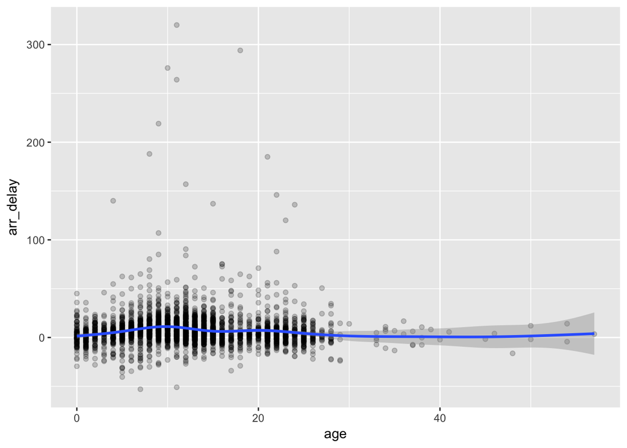

```r
flights %>% group_by(tailnum) %>%
  summarise(arr_delay = mean(arr_delay, na.rm=T)) %>%
  left_join(planes, by = c("tailnum")) %>%
  mutate(age = 2013 - year) %>%
  ggplot(aes(age, arr_delay)) +
  geom_point(alpha=.2, na.rm = T) +
  geom_smooth()
```

Planes seem to have slightly more delays at their 10-year-old phase, although that may have to do with outliers clustering around the densest area of airplane age.

4. What weather conditions make it more likely to see a delay?

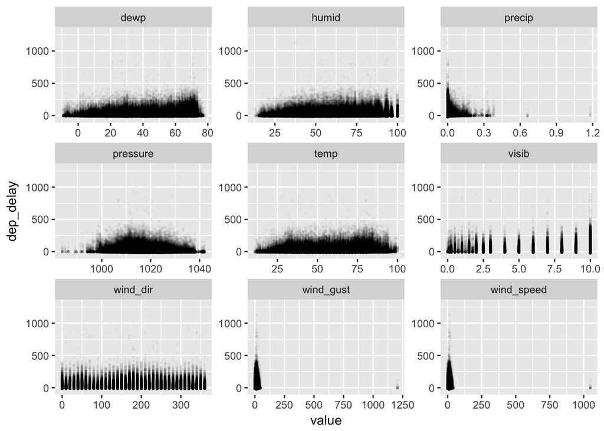

```r
flights %>%
    left_join(weather, by = c("origin", "year", "month", "day", "hour" )) %>%
    gather("weather_metric", "value", temp:visib) %>%
    ggplot(aes(value, dep_delay)) +
    geom_point(alpha = .02, size = .5, na.rm=T) +
    facet_wrap(~weather_metric, scales = "free")
```

Let’s explore the distribution of delays within barrometric pressure:

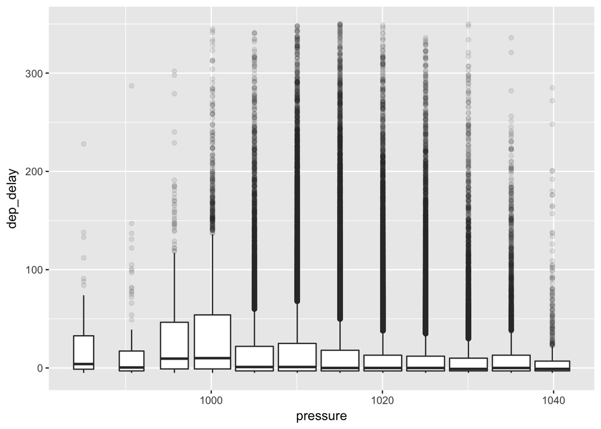

```r
# box plot pressure
flights %>%
    left_join(weather, by = c("origin", "year", "month", "day", "hour" )) %>%
  ggplot(aes(pressure, dep_delay)) +
  geom_boxplot(aes(group = cut_width(pressure, 5)), na.rm=T, outlier.alpha = 0.1) +
  ylim(-5, 350)
```

5. **What happened on June 13 2013? Display the spatial pattern of delays, and then use Google to cross-reference with the weather.**

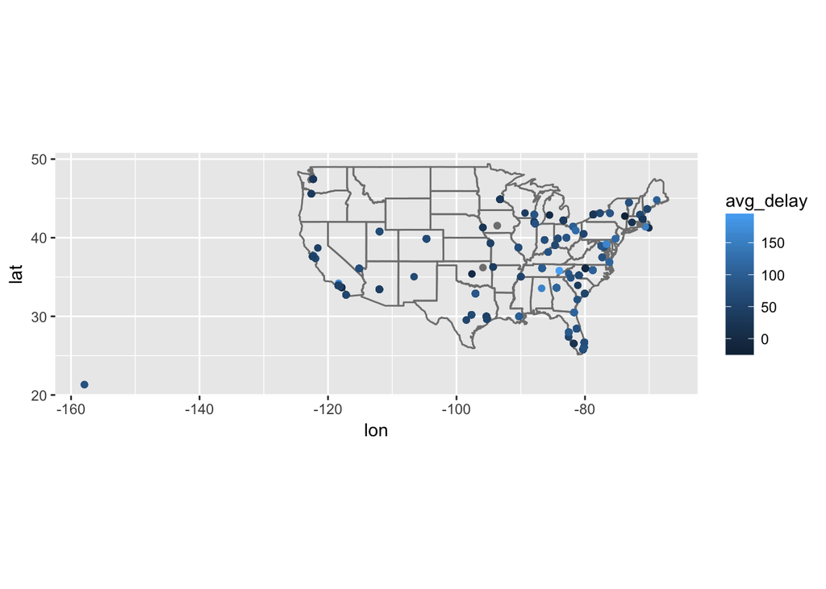

```r
flights3 <- group_by(flights, dest) %>%
filter(month == 6, day == 13) %>%
mutate(avg_delay = mean(arr_delay, na.rm = T))

flights3 %>%
      left_join(airports, c("dest" = "faa")) %>%
      ggplot(aes(lon, lat)) +
        borders("state") +
        geom_point(aes(color = avg_delay), na.rm = T) +
        coord_quickmap()
```

Pretty stout delays all over the eastern U.S. Google results talk about the derecho, a phenomenon that seems to cause thunderstorms.

## 13.5.1 Exercises

1. **What does it mean for a flight to have a missing `tailnum`? What do the tail numbers that don’t have a matching record in `planes` have in common? (Hint: one variable explains ~90% of the problems.)**

```r
flights %>%
  anti_join(planes, by = "tailnum") %>%
  count(carrier, sort = TRUE)
```

```
## # A tibble: 10 x 2
##    carrier     n
##      <chr> <int>
##  1      MQ 25397
##  2      AA 22558
##  3      UA  1693
##  4      9E  1044
##  5      B6   830
##  6      US   699
##  7      FL   187
##  8      DL   110
##  9      F9    50
## 10      WN    38
```

AA and MQ seem to omit tail numbers.

2. Filter flights to only show flights with planes that have flown at least 100 flights.

```r
century <- flights %>%
  count(tailnum) %>%
  filter(n >= 100)
century
```

```
## # A tibble: 1,218 x 2
##    tailnum     n
##      <chr> <int>
##  1  N0EGMQ   371
##  2  N10156   153
##  3  N10575   289
##  4  N11106   129
##  5  N11107   148
##  6  N11109   148
##  7  N11113   138
##  8  N11119   148
##  9  N11121   154
## 10  N11127   124
## # ... with 1,208 more rows
```

3. Combine `fueleconomy::vehicles` and `fueleconomy::common` to find only the records for the most common models.

```r
semi_join(vehicles, common)
```

```
## # A tibble: 14,531 x 12
##       id  make   model  year           class           trans
##    <int> <chr>   <chr> <int>           <chr>           <chr>
##  1  1833 Acura Integra  1986 Subcompact Cars Automatic 4-spd
##  2  1834 Acura Integra  1986 Subcompact Cars    Manual 5-spd
##  3  3037 Acura Integra  1987 Subcompact Cars Automatic 4-spd
##  4  3038 Acura Integra  1987 Subcompact Cars    Manual 5-spd
##  5  4183 Acura Integra  1988 Subcompact Cars Automatic 4-spd
##  6  4184 Acura Integra  1988 Subcompact Cars    Manual 5-spd
##  7  5303 Acura Integra  1989 Subcompact Cars Automatic 4-spd
##  8  5304 Acura Integra  1989 Subcompact Cars    Manual 5-spd
##  9  6442 Acura Integra  1990 Subcompact Cars Automatic 4-spd
## 10  6443 Acura Integra  1990 Subcompact Cars    Manual 5-spd
## # ... with 14,521 more rows, and 6 more variables: drive <chr>, cyl <int>,
## #   displ <dbl>, fuel <chr>, hwy <int>, cty <int>
```

4. Find the 48 hours (over the course of the whole year) that have the worst delays. Cross-reference it with the `weather` data. Can you see any patterns?

```r
#find delayedest 48 hrs
flights4 <- group_by(flights, year, month, day, origin) %>%
  summarize(avg_delay = mean(arr_delay, na.rm=T)) %>%
  mutate(neigh_sum = mean(avg_delay + lag(avg_delay), na.rm=T)) %>% #I would weight this combination of day averages by number of flights if I was a good person.
  arrange(desc(neigh_sum))

flights4
```

```
## # A tibble: 1,095 x 6
## # Groups:   year, month, day [365]
##     year month   day origin avg_delay neigh_sum
##    <int> <int> <int>  <chr>     <dbl>     <dbl>
##  1  2013     3     8    EWR 104.98120  161.9128
##  2  2013     3     8    JFK  61.20724  161.9128
##  3  2013     3     8    LGA  96.42982  161.9128
##  4  2013     7    22    EWR  55.25152  131.6693
##  5  2013     7    22    JFK  76.20132  131.6693
##  6  2013     7    22    LGA  55.68444  131.6693
##  7  2013     6    13    EWR  50.74121  128.7567
##  8  2013     6    13    JFK  63.71242  128.7567
##  9  2013     6    13    LGA  79.34733  128.7567
## 10  2013     7    10    EWR  56.88667  125.3156
## # ... with 1,085 more rows
```

```r
#group this bad boy into 48 hr periods
weather4 <- group_by(weather, year, month, day, origin) %>%
  summarize(avg_precip = mean(precip, na.rm=T),
            avg_visib = mean(visib, na.rm=T),
            avg_wind_speed = mean(wind_speed, na.rm=T)) %>%
  mutate(precip48 = mean(avg_precip + lag(avg_precip), na.rm=T),
         visib48 = mean(avg_visib + lag(avg_visib), na.rm=T),
         wind_speed48 = mean(avg_wind_speed + lag(avg_wind_speed), na.rm=T)) %>%
  arrange(visib48, desc(wind_speed48), desc(precip48))

weather4
```

```
## # A tibble: 1,092 x 10
## # Groups:   year, month, day [364]
##     year month   day origin   avg_precip avg_visib avg_wind_speed
##    <dbl> <dbl> <int>  <chr>        <dbl>     <dbl>          <dbl>
##  1  2013     1    13    EWR 0.0000000000  2.207917       2.013865
##  2  2013     1    13    JFK 0.0000000000  2.114583       5.945697
##  3  2013     1    13    LGA 0.0000000000  2.572500       5.658002
##  4  2013     1    30    EWR 0.0008333333  3.859167       4.699018
##  5  2013     1    30    JFK 0.0012500000  1.608750      12.658580
##  6  2013     1    30    LGA 0.0012500000  3.750000       8.487002
##  7  2013    10     6    EWR 0.0000000000  4.104167       6.569036
##  8  2013    10     6    JFK 0.0000000000  2.510417       9.445986
##  9  2013    10     6    LGA 0.0004166667  4.291667       8.726748
## 10  2013     1    12    EWR 0.0112500000  3.895833       5.705951
## # ... with 1,082 more rows, and 3 more variables: precip48 <dbl>,
## #   visib48 <dbl>, wind_speed48 <dbl>
```

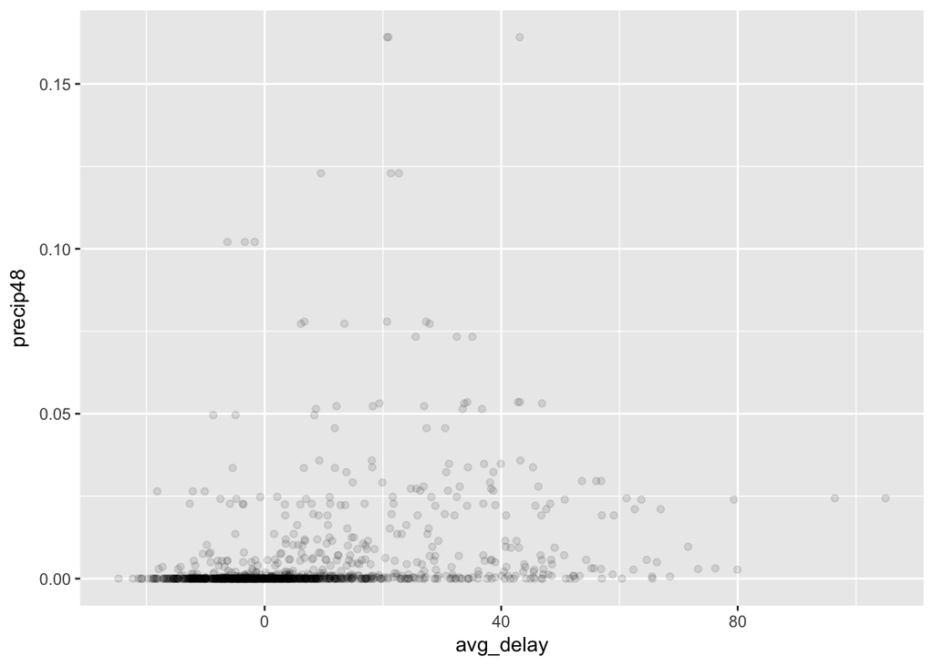

```r
# join
flight_weather <- left_join(flights4, weather4, c("year", "month", "day", "origin"))

# plot by precip
ggplot(flight_weather) +
  geom_point(aes(x=avg_delay, y=precip48), alpha=.1)
```